# 3. Поиск сайтов протеолиза белков протеосомой по данным IEDB

Антон Смирнов

24.01.2023

# Введение

The Immune Epitope Database (IEDB)Vita et al. (2019) - крупнейшая база данных по Т и В-клеточным эпитопам. Необходимо оценить частоту встречаемости аминокислот на С-конце эпитопа, так как с него как правило не идет процессинг антигена для МНС 1 класса и его можно считать сайтом разрезания протеасомы.

```r
library(RMySQL)
library(dplyr)
library(stringr)
```

#Определение необходимых источников данных и условий фильтрации

Установить соединение с БД, развернутой на локальном сервере.

```r
con = RMySQL::dbConnect(RMySQL::MySQL(),
                            dbname='iedb',
                            host='localhost',
                            port=3306,
                            user='stotoshka',
                            password='meowmeow')
```

Типы экспериментов в БД.

```sql
SELECT category, count(category) FROM assay_type GROUP BY category;
```

4 records

| category | count(category) |
| --- | --- |
| T Cell | 289 |
| MHC | 55 |
| B Cell | 84 |
| Naturally Processed | 7 |

```sql
SELECT category, assay_type  FROM assay_type at2 WHERE category = 'MHC' ;
```

Displaying records 1 - 10

| category | assay_type |
| --- | --- |
| MHC | purified MHC/competitive/fluorescence |
| MHC | lysate MHC/direct/radioactivity |
| MHC | cellular MHC/competitive/radioactivity |
| MHC | cellular MHC/T cell inhibition |
| MHC | purified MHC/competitive/fluorescence |
| MHC | purified MHC/direct/radioactivity |
| MHC | cellular MHC/direct/radioactivity |
| MHC | purified MHC/competitive/radioactivity |
| MHC | purified MHC/direct/fluorescence |
| MHC | purified MHC/direct/fluorescence |

```sql
SELECT category, assay_type  FROM assay_type at2 WHERE category = 'Naturally Processed' ;
```

7 records

| category | assay_type |
| --- | --- |
| Naturally Processed | secreted MHC/mass spectrometry |
| Naturally Processed | cellular MHC/mass spectrometry |
| Naturally Processed | coelution |
| Naturally Processed | Edman degradation |
| Naturally Processed | T cell recognition |
| Naturally Processed | High throughput multiplexed assay |
| Naturally Processed | mass spectrometry |

Необходимая нам информация содержится в таблицах mhc_elution и mhc_bind и связанных с ними.

```sql
SELECT DISTINCT at2.category,at2.assay_type FROM mhc_elution me
INNER JOIN assay_type at2 ON as_type_id  = at2.assay_type_id;
```

6 records

| category | assay_type |
| --- | --- |
| Naturally Processed | cellular MHC/mass spectrometry |
| Naturally Processed | coelution |
| Naturally Processed | secreted MHC/mass spectrometry |
| Naturally Processed | T cell recognition |
| Naturally Processed | Edman degradation |
| Naturally Processed | mass spectrometry |

```sql
SELECT DISTINCT at2.category,at2.assay_type FROM mhc_bind mb
INNER JOIN assay_type at2 ON as_type_id  = at2.assay_type_id
```

Displaying records 1 - 10

| category | assay_type |
| --- | --- |
| MHC | purified MHC/competitive/radioactivity |
| MHC | lysate MHC/direct/fluorescence |
| MHC | cellular MHC/competitive/fluorescence |
| MHC | x-ray crystallography |
| MHC | lysate MHC/direct/radioactivity |
| MHC | cellular MHC/direct/fluorescence |
| MHC | purified MHC/direct/phage display |
| MHC | cellular MHC/competitive/radioactivity |
| MHC | cellular MHC/T cell inhibition |
| MHC | purified MHC/direct/fluorescence |

# mhc_bind

Распределение по результатам

```sql
SELECT as_char_value, COUNT(as_char_value)  FROM mhc_bind GROUP BY as_char_value;
```

5 records

| as_char_value | COUNT(as_char_value) |
| --- | --- |
| Positive | 83161 |
| Positive-Low | 53433 |
| Negative | 575502 |
| Positive-High | 52177 |
| Positive-Intermediate | 45681 |

```sql
SELECT object_type, COUNT(object_type)  FROM object GROUP BY object_type;
```

Displaying records 1 - 10

| object_type | COUNT(object_type) |
| --- | --- |
| Accession Non-Sequence Molecule | 20893 |
| Accession Sequence Molecule | 213313 |
| Cell | 1521 |
| Complexed Molecule | 53805 |
| Derivative of Organism | 68048 |
| Discontinuous Region on Accession Non-Sequence Molecule | 1 |
| Discontinuous Region on Accession Sequence Molecule | 6741 |
| Fragment of a Natural Non-Sequence Molecule | 2628 |
| Fragment of a Natural Sequence Molecule | 3500629 |
| Infected Cell | 3455 |

```sql
SELECT object_sub_type, COUNT(object_sub_type)  FROM object GROUP BY object_sub_type;
```

Displaying records 1 - 10

| object_sub_type | COUNT(object_sub_type) |
| --- | --- |
| Anatomical Entity | 4948 |
| Bacterial display | 75 |
| Carbohydrate | 3655 |
| Carbohydrate fragment | 2395 |
| Cell | 9915 |
| Discontinuous protein residues | 6741 |
| Fatty acid | 52 |
| Fatty acid conjugate | 546 |
| Fatty acid fragment | 3 |
| Glycolipid | 2358 |

Всего строк в таблице

```sql
SELECT COUNT(*) FROM mhc_bind;
```

1 records

| COUNT(*) |
| --- |
| 809954 |

Отфильтруем строки с пустыми полями

```sql
CREATE TABLE filtered_bind
AS (SELECT mhc_bind_id, reference_id, curated_epitope_id, as_char_value, mhc_allele_restriction_id
    FROM mhc_bind
    WHERE mhc_bind_id IS NOT NULL AND
          reference_id IS NOT NULL AND
          curated_epitope_id IS NOT NULL AND
          as_char_value IS NOT NULL AND
          mhc_allele_restriction_id IS NOT NULL);
```

```sql
CREATE INDEX filtered_bind_index ON filtered_bind (mhc_bind_id,curated_epitope_id,mhc_allele_restriction_id);
```

Количество строк

```sql
SELECT COUNT(*) FROM filtered_bind;
```

1 records

| COUNT(*) |
| --- |
| 809954 |

# mhc_elution

Распределение по результатам

```sql
SELECT as_char_value, COUNT(as_char_value)  FROM mhc_elution GROUP BY as_char_value;
```

4 records

| as_char_value | COUNT(as_char_value) |
| --- | --- |
| Negative | 23445 |
| Positive | 3856075 |
| Positive-High | 1437 |
| Positive-Low | 108 |

Всего строк в таблице

```sql
SELECT COUNT(*) FROM mhc_elution;
```

1 records

| COUNT(*) |
| --- |
| 3881065 |

Отфильтруем строки с пустыми полями

```sql
CREATE TABLE filtered_elution
AS (SELECT mhc_elution_id, reference_id, curated_epitope_id, as_char_value, mhc_allele_restriction_id, h_organism_id, ant_type, ant_ref_name, ant_object_id, apc_cell_type, apc_tissue_type, apc_origin
    FROM mhc_elution
    WHERE mhc_elution_id IS NOT NULL AND
          reference_id IS NOT NULL AND
          curated_epitope_id IS NOT NULL AND
          as_char_value IS NOT NULL AND
          mhc_allele_restriction_id IS NOT NULL AND
          h_organism_id = 9606 AND
          ant_type = 'Epitope');
```

```sql
CREATE INDEX filtered_elution_index ON filtered_elution (mhc_elution_id,curated_epitope_id,mhc_allele_restriction_id);
```

Количество строк

```sql
SELECT COUNT(*) FROM filtered_elution;
```

1 records

| COUNT(*) |
| --- |
| 3597663 |

Нам необходима информация о МНС и о эпитопе. Подготовим по отдельности и объединим.

# Эпитопы

```sql
SELECT DISTINCT COUNT(e_object_id) FROM curated_epitope;
```

1 records

| COUNT(e_object_id) |
| --- |
| 3610928 |

```sql
SELECT e_region_domain_flag, COUNT(e_region_domain_flag) FROM curated_epitope
GROUP BY e_region_domain_flag;
```

5 records

| e_region_domain_flag | COUNT(e_region_domain_flag) |
| --- | --- |
| NA | 0 |
| Epitope containing region/antigenic site | 1019516 |
| Exact Epitope | 2582030 |
| Partial Epitope | 8981 |
| Repetitive antigenic region | 95 |

```sql
SELECT e_ev, COUNT(e_ev) FROM curated_epitope
GROUP BY e_ev;
```

7 records

| e_ev | COUNT(e_ev) |
| --- | --- |
| NA | 0 |
| Not determined | 76394 |
| Exact match to reference information | 17520 |
| Representative selection | 841918 |
| Internal Identifier-no external match available | 31082 |
| Author provided Identifier | 429490 |
| Imperfect match | 145 |

```sql
CREATE TABLE filtered_epitope_cur
AS (SELECT curated_epitope_id, e_name, source_antigen_accession, description ,e_region_domain_flag, e_ev, linear_peptide_seq, e_ref_start,e_ref_end, `database`, name, sequence, organism_name
    FROM curated_epitope
    INNER JOIN epitope_object eo ON eo.object_id = e_object_id
    INNER JOIN epitope e ON e.epitope_id = eo.epitope_id
    INNER JOIN source s ON s.accession = source_antigen_accession
    WHERE e_region_domain_flag = 'Exact Epitope' AND
          linear_peptide_seq IS NOT NULL AND
          linear_peptide_modification IS NULL AND
          sequence IS NOT NULL);
```

```sql
CREATE INDEX filtered_epitope_cur_index ON filtered_epitope_cur (curated_epitope_id);
```

```sql
SELECT COUNT(curated_epitope_id) FROM filtered_epitope_cur;
```

1 records

| COUNT(curated_epitope_id) |
| --- |
| 2276914 |

# MHC

```sql
SELECT COUNT(*) FROM mhc_allele_restriction;
```

1 records

| COUNT(*) |
| --- |
| 22675 |

```sql
SELECT restriction_level, COUNT(restriction_level) FROM mhc_allele_restriction
GROUP BY restriction_level;
```

6 records

| restriction_level | COUNT(restriction_level) |
| --- | --- |
| complete molecule | 16184 |
| locus | 53 |
| haplotype | 53 |
| class | 38 |
| partial molecule | 6222 |
| serotype | 125 |

```sql
SELECT class, COUNT(class) FROM mhc_allele_restriction
GROUP BY class;
```

3 records

| class | COUNT(class) |
| --- | --- |
| II | 6511 |
| I | 15964 |
| non classical | 200 |

Нам нужны человеческие (NCBI Taxonomy ID 9606) МНС 1 класса.

```sql
CREATE TABLE filtered_mhc
AS (SELECT mhc_allele_restriction_id, restriction_level,displayed_restriction, organism_ncbi_tax_id,class, chain_i_name
    FROM mhc_allele_restriction
    WHERE mhc_allele_restriction_id IS NOT NULL AND
          restriction_level = 'complete molecule' AND
          organism_ncbi_tax_id = 9606 AND
          class = 'I');
```

```sql
CREATE INDEX filtered_mhc_index ON filtered_mhc (mhc_allele_restriction_id);
```

```sql
SELECT COUNT(*) FROM filtered_mhc;
```

1 records

| COUNT(*) |
| --- |
| 12133 |

# Соединим вместе

```sql
CREATE TABLE epi_mhc_bind
AS (SELECT fb.mhc_bind_id, fb.reference_id, fb.as_char_value,
e_name, source_antigen_accession, description ,e_region_domain_flag, e_ev, linear_peptide_seq, e_ref_start,e_ref_end, `database`, name, sequence, organism_name,
restriction_level,displayed_restriction, organism_ncbi_tax_id,class, chain_i_name
    FROM filtered_bind fb
    INNER JOIN filtered_mhc fm ON fm.mhc_allele_restriction_id = fb.mhc_allele_restriction_id
    INNER JOIN filtered_epitope_cur fe ON fe.curated_epitope_id = fb.curated_epitope_id);
```

```sql
CREATE INDEX epi_mhc_bind_index ON epi_mhc_bind (mhc_bind_id);
```

```sql
SELECT COUNT(mhc_bind_id) FROM epi_mhc_bind;
```

1 records

| COUNT(mhc_bind_id) |
| --- |
| 167680 |

```sql
CREATE TABLE epi_mhc_elution
AS (SELECT fel.mhc_elution_id, fel.reference_id, fel.as_char_value,
apc_cell_type, apc_tissue_type, apc_origin,
e_name, source_antigen_accession, description ,e_region_domain_flag, e_ev, linear_peptide_seq, e_ref_start,e_ref_end, `database`, name, sequence, organism_name,
restriction_level,displayed_restriction, organism_ncbi_tax_id,class, chain_i_name
    FROM filtered_elution fel
    INNER JOIN filtered_mhc fm ON fm.mhc_allele_restriction_id = fel.mhc_allele_restriction_id
    INNER JOIN filtered_epitope_cur fe ON fe.curated_epitope_id = fel.curated_epitope_id);
```

```sql
CREATE INDEX epi_mhc_elution_index ON epi_mhc_elution (mhc_elution_id);
```

```sql
SELECT COUNT(mhc_elution_id) FROM epi_mhc_elution;
```

1 records

| COUNT(mhc_elution_id) |
| --- |
| 971195 |

# Обработка данных

```r
bind.assays = RMySQL::dbReadTable(con, "epi_mhc_bind") %>% select(-mhc_bind_id)
elution.assays = RMySQL::dbReadTable(con, "epi_mhc_elution")%>% select(-one_of("mhc_elution_id","apc_cell_type","apc_tissue_type","apc_origin"))
all.assays = rbind.data.frame(bind.assays,elution.assays)
```

Для каждой записи есть ссылка на источник.

```r
sum(is.na(all.assays$reference_id))
```

```
## [1] 0
```

Распределение результатов экспериментов

```r
table(bind.assays$as_char_value)
```

```
##
##              Negative              Positive         Positive-High
##                 85578                 10838                 25643
## Positive-Intermediate          Positive-Low
##                 20665                 24956
```

```r
table(elution.assays$as_char_value)
```

```
##
##      Negative      Positive Positive-High  Positive-Low
##             5        971138             1            51
```

```r
table(all.assays$as_char_value)
```

```
##
##              Negative              Positive         Positive-High
##                 85583                981976                 25644
## Positive-Intermediate          Positive-Low
##                 20665                 25007
```

Берем С-концевые аминокислоты эпитопов и +1 после неё, разделив на положительные и отрицательные случаи

```r
neg.assays = subset.data.frame(all.assays, as_char_value == "Negative")[,c("linear_peptide_seq","sequence")]
pos.assays = subset.data.frame(all.assays, as_char_value != "Negative")[,c("linear_peptide_seq","sequence")]
```

## Положительные случаи

```r
locations = stringr::str_locate_all(pos.assays$sequence, pos.assays$linear_peptide_seq)
```

```r
C.terms = lapply(seq_along(locations),function(i, seq){
    str_sub(pos.assays$sequence[i],locations[[i]][,"end"],locations[[i]][,"end"]+1)
})
```

```r
pairs = unlist(C.terms)
V1 = str_sub(pairs,1,1)
V2 = str_sub(pairs,2,2)
pairs.df = cbind.data.frame(V1,V2)
```

```r
probs = data.frame(matrix(0,nrow = 20,ncol = 20))
colnames(probs) = unlist(str_split("ACDEFGHIKLMNPQRSTVWY",pattern = ""))
epitopes = unique(pos.assays$linear_peptide_seq)
print(length(epitopes))
```

```
## [1] 340940
```

```r
for (i in seq_len(nrow(probs))) {
  p = table(sapply(epitopes,str_sub,i,i))
  for (j in colnames(probs)) {
      probs[i,j] = p[j]
  }
}
probs = probs / length(epitopes)
head(probs)
```

```
##            A           C          D          E          F          G          H
## 1 0.09800551 0.002267261 0.03986625 0.05650261 0.05652021 0.05343462 0.03418490
## 2 0.08369801 0.002053147 0.01452162 0.13745234 0.02704875 0.01897695 0.01702939
## 3 0.08641110 0.003936176 0.08234293 0.04158210 0.06939051 0.03360709 0.02917522
## 4 0.06350678 0.003053323 0.09116853 0.11097554 0.02753564 0.07338241 0.02359653
## 5 0.07007685 0.003654602 0.04690855 0.06344225 0.04300463 0.07285739 0.03439901
## 6 0.06635185 0.004282278 0.03916232 0.05458145 0.04325394 0.06310201 0.02945386
##            I          K          L          M           N           P
## 1 0.05370446 0.07998181 0.07569367 0.02185135 0.030492169 0.009767114
## 2 0.04634246 0.01159735 0.14693788 0.02055200 0.008001408 0.096063824
## 3 0.07300405 0.05727107 0.10151346 0.02716607 0.040831231 0.040819499
## 4 0.03848184 0.06096674 0.07248196 0.01061770 0.041013081 0.098870769
## 5 0.06352731 0.05736200 0.08793043 0.01370329 0.038475978 0.075564615
## 6 0.07497214 0.05006453 0.10540858 0.01605561 0.037675251 0.068117557
##            Q          R          S          T          V           W          Y
## 1 0.03671907 0.08275356 0.09557987 0.05510354 0.06310495 0.006012788 0.04845427
## 2 0.05021705 0.06670382 0.06606148 0.06794744 0.07386637 0.004332141 0.04059659
## 3 0.03771925 0.04716666 0.06312841 0.03766645 0.05921276 0.015369273 0.05268669
## 4 0.04803778 0.03774858 0.07696369 0.04735731 0.04656245 0.007552649 0.02012671
## 5 0.04251188 0.04868892 0.07148179 0.05224086 0.07916936 0.009667390 0.02530651
## 6 0.04712266 0.04589371 0.07347627 0.06435443 0.08413504 0.007919282 0.02447351
```

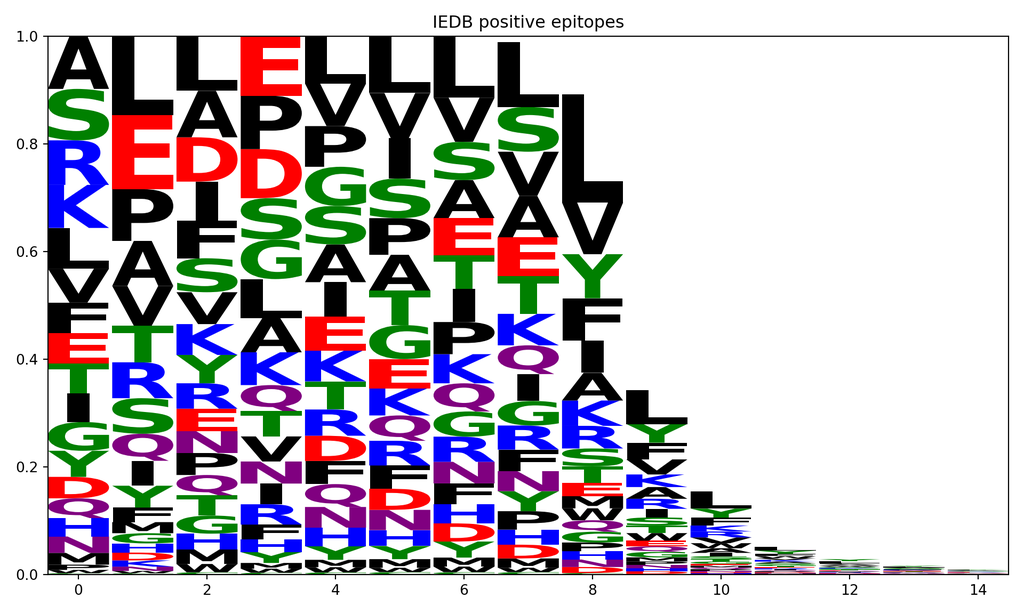

```python
import logomaker
import matplotlib.pyplot as plt

probs = r.probs
fig,ax = plt.subplots(figsize = (10,6))
ax.set_title("IEDB positive epitopes")
logo = logomaker.Logo(probs.iloc[0:15,:], color_scheme = "chemistry", ax = ax)
fig.tight_layout()
plt.show()
```

Можно заметить, что на N-конце распределение остатков более менее равномерное, когда на C-конце преобладают гидрофобные и основные остатки.

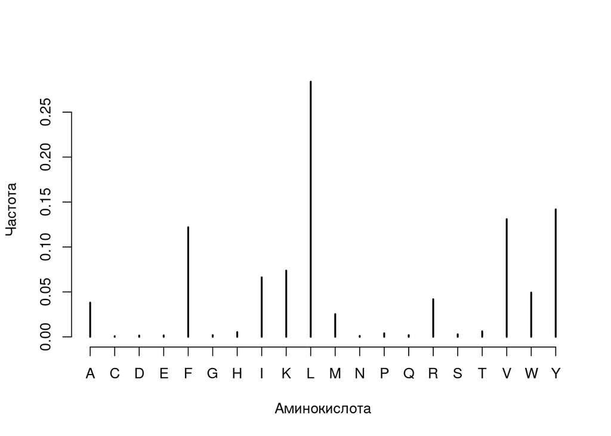

```r
plot(round(table(pairs.df$V1) / nrow(pairs.df), 5),ylab = "Частота", xlab = "Аминокислота")
```

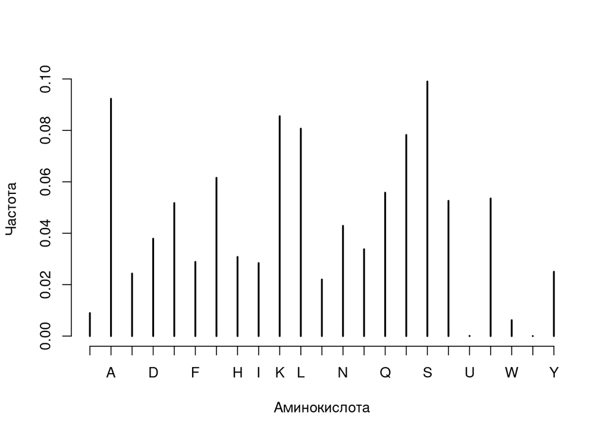

```r
plot(round(table(pairs.df$V2) / nrow(pairs.df), 5),ylab = "Частота", xlab = "Аминокислота")
```

Из этих двух графиков видно, что не так важна какая аминокислота идет после сайта разрезания, важно что разрезание идет по гидрофобным и положительно заряженным аминокислотам.

## Отрицательные случаи

```r
locations = stringr::str_locate_all(neg.assays$sequence, neg.assays$linear_peptide_seq)
```

```r
C.terms = lapply(seq_along(locations),function(i, seq){
    str_sub(neg.assays$sequence[i],locations[[i]][,"end"],locations[[i]][,"end"]+1)
})
```

```r
pairs = unlist(C.terms)
V1 = str_sub(pairs,1,1)
V2 = str_sub(pairs,2,2)
pairs.df = cbind.data.frame(V1,V2)
```

```r
probs = data.frame(matrix(0,nrow = 20,ncol = 20))
colnames(probs) = unlist(str_split("ACDEFGHIKLMNPQRSTVWY",pattern = ""))
epitopes = unique(neg.assays$linear_peptide_seq)
print(length(epitopes))
```

```
## [1] 15875
```

```r
for (i in seq_len(nrow(probs))) {
  p = table(sapply(epitopes,str_sub,i,i))
  for (j in colnames(probs)) {
      probs[i,j] = p[j]
  }
}
probs = probs / length(epitopes)
head(probs)
```

```
##            A          C          D          E          F          G          H
## 1 0.07370079 0.01562205 0.04113386 0.05782677 0.05568504 0.05656693 0.02267717
## 2 0.06948031 0.01165354 0.01662992 0.05379528 0.03590551 0.02381102 0.01222047
## 3 0.07319685 0.01480315 0.05744882 0.05058268 0.05593701 0.04850394 0.02185827
## 4 0.06607874 0.01700787 0.06324409 0.06412598 0.04163780 0.06752756 0.02299213
## 5 0.06519685 0.01738583 0.04674016 0.04976378 0.04768504 0.06582677 0.02355906
## 6 0.06166929 0.02009449 0.04806299 0.04459843 0.05184252 0.06702362 0.02343307
##            I          K          L          M          N          P          Q
## 1 0.06507087 0.06840945 0.09190551 0.03319685 0.04075591 0.02878740 0.03174803
## 2 0.07930709 0.01499213 0.15867717 0.04585827 0.01398425 0.08522835 0.04170079
## 3 0.06677165 0.05776378 0.09662992 0.03357480 0.04888189 0.04251969 0.03458268
## 4 0.05234646 0.06053543 0.08711811 0.02324409 0.04944882 0.05851969 0.04226772
## 5 0.06645669 0.05631496 0.09335433 0.02437795 0.05600000 0.04686614 0.03275591
## 6 0.06639370 0.04818898 0.09902362 0.02582677 0.05360630 0.04447244 0.03634646
##            R          S          T          V          W          Y
## 1 0.06116535 0.07514961 0.05480315 0.06185827 0.01662992 0.04730709
## 2 0.03105512 0.07124409 0.10154331 0.08478740 0.00888189 0.03924409
## 3 0.05644094 0.07319685 0.05014173 0.05285039 0.01688189 0.04743307
## 4 0.04724409 0.07061417 0.05606299 0.05656693 0.01688189 0.03653543
## 5 0.05335433 0.07256693 0.06009449 0.06570079 0.01851969 0.03748031
## 6 0.05253543 0.07401575 0.06992126 0.06053543 0.01618898 0.03622047
```

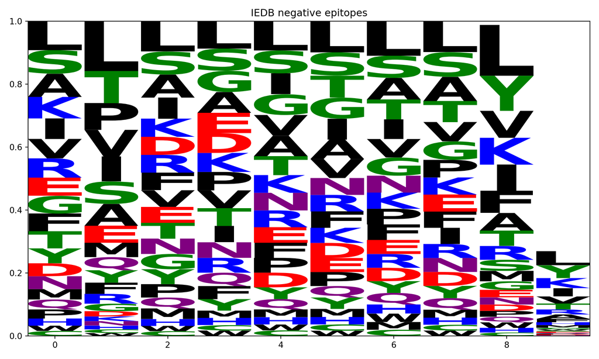

```python
import logomaker
import matplotlib.pyplot as plt

probs = r.probs
fig,ax = plt.subplots(figsize = (10,6))
ax.set_title("IEDB negative epitopes")
logo = logomaker.Logo(probs.iloc[0:10,:], color_scheme = "chemistry", ax = ax)
fig.tight_layout()
plt.show()
```

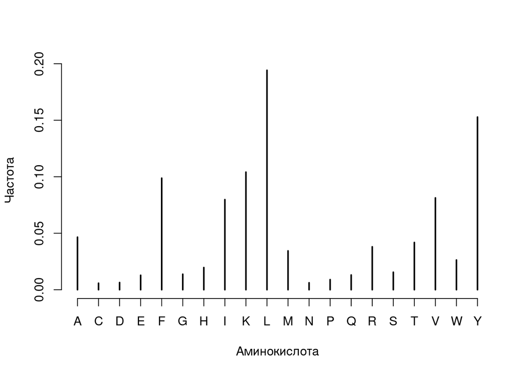

```r
plot(round(table(pairs.df$V1) / nrow(pairs.df), 5),ylab = "Частота", xlab = "Аминокислота")
```

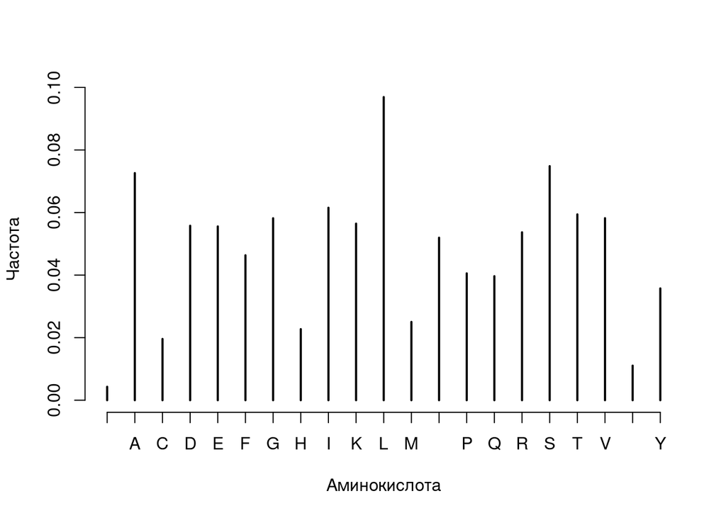

```r
plot(round(table(pairs.df$V2) / nrow(pairs.df), 5),ylab = "Частота", xlab = "Аминокислота")
```

Для отрицательных случаев получились похожие результаты.

Удалить созданные промежуточные таблицы

```sql
DROP TABLE IF EXISTS filtered_bind, filtered_elution, filtered_epitope_cur,filtered_mhc, epi_mhc_bind,epi_mhc_elution;
```

Vita, Randi, Swapnil Mahajan, James A Overton, Sandeep Kumar Dhanda, Sheridan Martini, Jason R Cantrell, Daniel K Wheeler, Alessandro Sette, and Bjoern Peters. 2019. “The Immune Epitope Database (IEDB): 2018 Update.” *Nucleic Acids Research* 47 (D1): D339–43. https://doi.org/10.1093/nar/gky1006.